# Real-world Data Wrangling

In this project, you will apply the skills you acquired in the course to gather and wrangle real-world data with two datasets of your choice.

You will retrieve and extract the data, assess the data programmatically and visually, accross elements of data quality and structure, and implement a cleaning strategy for the data. You will then store the updated data into your selected database/data store, combine the data, and answer a research question with the datasets.

Throughout the process, you are expected to:

1. Explain your decisions towards methods used for gathering, assessing, cleaning, storing, and answering the research question
2. Write code comments so your code is more readable

## 1. Gather data

In this section, you will extract data using two different data gathering methods and combine the data. Use at least two different types of data-gathering methods.

### **1.1.** Problem Statement

Since I am getting my bachelor's in data analytics, I wanted to look up jobs and salaries for "data based" jobs. The goal is to see what is out there and what the pay looks like. Would like to know the average salary of entry level jobs, as well as the most common job titles.

### **1.2.** Gather at least two datasets using two different data gathering methods

List of data gathering methods:

- Download data manually
- Programmatically downloading files
- Gather data by accessing APIs
- Gather and extract data from HTML files using BeautifulSoup
- Extract data from a SQL database

Each dataset must have at least two variables, and have greater than 500 data samples within each dataset.

For each dataset, briefly describe why you picked the dataset and the gathering method (2-3 full sentences), including the names and significance of the variables in the dataset. Show your work (e.g., if using an API to download the data, please include a snippet of your code).

Load the dataset programmtically into this notebook.

```python
# Import libraries
import pandas as pd
import numpy as np
# Manually setting kaggle keys due to not have root file access for the json file it wants
import os
os.environ['KAGGLE_USERNAME'] = 'michaelmonroe'
os.environ['KAGGLE_KEY'] = '8192b806bba0215996865c1efc95acf2'
from kaggle import api
import kaggle
import zipfile
import matplotlib.pyplot as plt
import json
```

#### **Dataset 1**

Found this dataset with information pertaining to my problem statement. Has a good amount of data and explained nicely on kaggle.

Type: CSV File

Method: Downloaded from kaggle : https://www.kaggle.com/datasets/bismasajjad/global-ai-job-market-and-salary-trends-2025

Dataset variables:

- job_id: Unique identifier for each job posting
- job_title: Standardized job title
- salary_usd: Annual salary in USD
- salary_currency: Original salary currency
- experience_level: EN (Entry), MI (Mid), SE (Senior), EX (Executive)
- employment_type: FT (Full-time), PT (Part-time), CT (Contract), FL (Freelance)
- company_location: Country where company is located
- company_size: S (Small <50), M (Medium 50-250), L (Large >250)
- employee_residence: Country where employee resides
- remote_ratio: 0 (No remote), 50 (Hybrid), 100 (Fully remote)
- required_skills: Top 5 required skills (comma-separated)
- education_required: Minimum education requirement
- years_experience: Required years of experience
- industry: Industry sector of the company
- posting_date: Date when job was posted
- application_deadline: Application deadline
- job_description_length: Character count of job description
- benefits_score: Numerical score of benefits package (1-10)
- company_name: name of company

```python
# Dataset downloaded from kaggle and saved to folder
df_d_raw = pd.read_csv('ai_job_dataset.csv')
df_d_raw.head()
```

|  | job_id | job_title | salary_usd | salary_currency | experience_level | employment_type | company_location | company_size | employee_residence | remote_ratio | required_skills | education_required | years_experience | industry | posting_date | application_deadline | job_description_length | benefits_score | company_name |
| --- | --- | --- | --- | --- | --- | --- | --- | --- | --- | --- | --- | --- | --- | --- | --- | --- | --- | --- | --- |
| 0 | AI00001 | AI Research Scientist | 90376 | USD | SE | CT | China | M | China | 50 | Tableau, PyTorch, Kubernetes, Linux, NLP | Bachelor | 9 | Automotive | 2024-10-18 | 2024-11-07 | 1076 | 5.9 | Smart Analytics |
| 1 | AI00002 | AI Software Engineer | 61895 | USD | EN | CT | Canada | M | Ireland | 100 | Deep Learning, AWS, Mathematics, Python, Docker | Master | 1 | Media | 2024-11-20 | 2025-01-11 | 1268 | 5.2 | TechCorp Inc |
| 2 | AI00003 | AI Specialist | 152626 | USD | MI | FL | Switzerland | L | South Korea | 0 | Kubernetes, Deep Learning, Java, Hadoop, NLP | Associate | 2 | Education | 2025-03-18 | 2025-04-07 | 1974 | 9.4 | Autonomous Tech |
| 3 | AI00004 | NLP Engineer | 80215 | USD | SE | FL | India | M | India | 50 | Scala, SQL, Linux, Python | PhD | 7 | Consulting | 2024-12-23 | 2025-02-24 | 1345 | 8.6 | Future Systems |
| 4 | AI00005 | AI Consultant | 54624 | EUR | EN | PT | France | S | Singapore | 100 | MLOps, Java, Tableau, Python | Master | 0 | Media | 2025-04-15 | 2025-06-23 | 1989 | 6.6 | Advanced Robotics |

#### Dataset 2

Also found this on kaggle while searching for datasets. Well documented on the site and has usable data.

Type: CSV File

Method: The data was gathered using the "API" method from kaggle. https://www.kaggle.com/datasets/adilshamim8/salaries-for-data-science-jobs

Dataset variables:

- work_year: Ranges from the year 2020 to 2025
- experience_level: EN: Entry-level / Junior, MI: Mid-level / Intermediate, SE: Senior-level, EX: Executive / Director
- employment_type: FT: Full-time, PT: Part-time, CT: Contract, FL: Freelance
- job_title: Title of job
- salary: Salary in original reported currency
- salary_currency: Currency type
- salary_in_usd: Converted to US dollars
- employee_residence: Country employee lives
- remote_ratio: 0: No remote work (On-site). 50: Hybrid (partially remote), 100: Fully remote
- company_location: Company's location
- company_size: S: Small (1–50 employees). M: Medium (51–500 employees), L: Large (501+ employees)

```python
# DStaset called with api from kaggle
kaggle.api.dataset_download_files('adilshamim8/salaries-for-data-science-jobs', path='./',unzip=True)
# Reading in the .csv
df_api_raw = pd.read_csv('salaries.csv')
df_api_raw.head()
```

```
Dataset URL: https://www.kaggle.com/datasets/adilshamim8/salaries-for-data-science-jobs
```

|  | work_year | experience_level | employment_type | job_title | salary | salary_currency | salary_in_usd | employee_residence | remote_ratio | company_location | company_size |
| --- | --- | --- | --- | --- | --- | --- | --- | --- | --- | --- | --- |
| 0 | 2025 | SE | FT | Software Engineer | 218900 | USD | 218900 | US | 100 | US | M |
| 1 | 2025 | SE | FT | Software Engineer | 186065 | USD | 186065 | US | 100 | US | M |
| 2 | 2025 | SE | FT | System Engineer | 158000 | USD | 158000 | US | 0 | US | M |
| 3 | 2025 | SE | FT | System Engineer | 140000 | USD | 140000 | US | 0 | US | M |
| 4 | 2025 | SE | FT | Data Engineer | 164600 | USD | 164600 | US | 0 | US | M |

#### Dataset 3

Also found this on kaggle while searching for datasets.

Type: json file

Method: Downloaded json file. https://www.kaggle.com/datasets/ghostjobs/january-2025-60k-jobs-indeed

Dataset variables:

- id: record id
- title: job title
- company_name: company name
- job_url: link to job on indeed
- job_url_direct: direct link to company job posting
- location: location
- description: description
- company_url: company page on indeed
- company_url_direct: company website
- job_type: fulltime, parttime, etc
- compensation: pay
- date_posted: date posted
- emails: company email
- is_remote: is the job remote
- listing_type: listing type
- job_level: like entry, senior, etc
- company_industry: industry the company is in
- company_addresses: location of company
- company_num_employees: number of employees at company
- company_revenue: company revenue
- company_description: description of the company
- company_logo: company logo
- banner_photo_url: photo of company banner
- job_function: function of the job

```python
# Read JSON file in
with open('job_report.json','r') as file:
    data = json.load(file)

# Set up dataframe
df_json_raw = pd.DataFrame(data['jobs'])
df_json_raw.head()
```

|  | id | title | company_name | job_url | job_url_direct | location | description | company_url | company_url_direct | job_type | ... | listing_type | job_level | company_industry | company_addresses | company_num_employees | company_revenue | company_description | company_logo | banner_photo_url | job_function |
| --- | --- | --- | --- | --- | --- | --- | --- | --- | --- | --- | --- | --- | --- | --- | --- | --- | --- | --- | --- | --- | --- |
| 0 | in-a0162397741337e8 | White Mountain Trail Crew Field Coordinator | Appalachian Mountain Club | https://www.indeed.com/viewjob?jk=a01623977413... | https://www.paycomonline.net/v4/ats/web.php/jo... | {'country': 'US', 'city': 'Gorham', 'state': '... | April 7\-Oct 31, 2025\. Dates can be flexible,... | https://www.indeed.com/cmp/Appalachian-Mountai... | None | [] | ... | None | None | None | None | 201 to 500 | $25M to $100M (USD) | At the Appalachian Mountain Club (AMC), connec... | https://d2q79iu7y748jz.cloudfront.net/s/_squar... | None | None |
| 1 | in-de356b3c36971bc8 | Assistant Community Manager \| Lancaster Villag... | CSM Corporation | https://www.indeed.com/viewjob?jk=de356b3c3697... | https://recruiting2.ultipro.com/CSM1000CSMM/Jo... | {'country': 'US', 'city': 'Plymouth', 'state':... | The Lancaster Village Apartments are looking f... | https://www.indeed.com/cmp/Csm-Corporation | http://csmcorp.net/ | [fulltime] | ... | None | None | Real Estate | CSM Corporation Headquarters - 500 Washington ... | 1,001 to 5,000 | None | CSM Corporation creates exceptional spaces whe... | https://d2q79iu7y748jz.cloudfront.net/s/_squar... | None | None |
| 2 | in-0719c4ebeb2ee8e6 | PT Weekend Night Auditor (Friday and Saturday ... | None | https://www.indeed.com/viewjob?jk=0719c4ebeb2e... | https://recruiting2.ultipro.com/CSM1000CSMM/Jo... | {'country': 'US', 'city': 'Lansing', 'state': ... | * Performs the manager\-on\-duty role during 3... | None | None | [parttime] | ... | None | None | None | None | None | None | None | None | None | None |
| 3 | in-042b575494ab385a | Leasing Consultant | CSM Corporation | https://www.indeed.com/viewjob?jk=042b575494ab... | https://recruiting2.ultipro.com/CSM1000CSMM/Jo... | {'country': 'US', 'city': 'Gladstone', 'state'... | This position is responsible for the leasing a... | https://www.indeed.com/cmp/Csm-Corporation | http://csmcorp.net/ | [fulltime] | ... | None | None | Real Estate | CSM Corporation Headquarters - 500 Washington ... | 1,001 to 5,000 | None | CSM Corporation creates exceptional spaces whe... | https://d2q79iu7y748jz.cloudfront.net/s/_squar... | None | None |
| 4 | in-a013bb09e245a9d4 | Assistant General Manager \| Residence Inn Denv... | None | https://www.indeed.com/viewjob?jk=a013bb09e245... | https://recruiting2.ultipro.com/CSM1000CSMM/Jo... | {'country': 'US', 'city': 'Englewood', 'state'... | **Salary: $60,000\-65,000**\n\n\n**Benefits:**... | None | None | [fulltime] | ... | None | None | None | None | None | None | None | None | None | None |

5 rows × 24 columns

## 2. Assess data

Assess the data according to data quality and tidiness metrics using the report below.

List **two** data quality issues and **two** tidiness issues. Assess each data issue visually **and** programmatically, then briefly describe the issue you find. **Make sure you include justifications for the methods you use for the assessment.**

### Quality Issue 1:

```python
# Inspecting the dataframe visually
df_d_raw.head(20)
```

|  | job_id | job_title | salary_usd | salary_currency | experience_level | employment_type | company_location | company_size | employee_residence | remote_ratio | required_skills | education_required | years_experience | industry | posting_date | application_deadline | job_description_length | benefits_score | company_name |
| --- | --- | --- | --- | --- | --- | --- | --- | --- | --- | --- | --- | --- | --- | --- | --- | --- | --- | --- | --- |
| 0 | AI00001 | AI Research Scientist | 90376 | USD | SE | CT | China | M | China | 50 | Tableau, PyTorch, Kubernetes, Linux, NLP | Bachelor | 9 | Automotive | 2024-10-18 | 2024-11-07 | 1076 | 5.9 | Smart Analytics |
| 1 | AI00002 | AI Software Engineer | 61895 | USD | EN | CT | Canada | M | Ireland | 100 | Deep Learning, AWS, Mathematics, Python, Docker | Master | 1 | Media | 2024-11-20 | 2025-01-11 | 1268 | 5.2 | TechCorp Inc |
| 2 | AI00003 | AI Specialist | 152626 | USD | MI | FL | Switzerland | L | South Korea | 0 | Kubernetes, Deep Learning, Java, Hadoop, NLP | Associate | 2 | Education | 2025-03-18 | 2025-04-07 | 1974 | 9.4 | Autonomous Tech |
| 3 | AI00004 | NLP Engineer | 80215 | USD | SE | FL | India | M | India | 50 | Scala, SQL, Linux, Python | PhD | 7 | Consulting | 2024-12-23 | 2025-02-24 | 1345 | 8.6 | Future Systems |
| 4 | AI00005 | AI Consultant | 54624 | EUR | EN | PT | France | S | Singapore | 100 | MLOps, Java, Tableau, Python | Master | 0 | Media | 2025-04-15 | 2025-06-23 | 1989 | 6.6 | Advanced Robotics |
| 5 | AI00006 | AI Architect | 123574 | EUR | SE | CT | Germany | M | Germany | 50 | Data Visualization, R, SQL, Linux | Associate | 7 | Healthcare | 2024-08-31 | 2024-10-04 | 819 | 5.9 | Neural Networks Co |
| 6 | AI00007 | Principal Data Scientist | 79670 | GBP | MI | FL | United Kingdom | S | United Kingdom | 0 | R, Docker, MLOps | Associate | 3 | Gaming | 2024-12-29 | 2025-02-28 | 1936 | 6.3 | DataVision Ltd |
| 7 | AI00008 | NLP Engineer | 70640 | EUR | EN | FL | France | L | France | 0 | Python, SQL, Computer Vision, Java, Azure | Master | 0 | Healthcare | 2024-06-07 | 2024-07-01 | 1286 | 7.6 | Cloud AI Solutions |
| 8 | AI00009 | Data Analyst | 160710 | USD | SE | CT | Singapore | L | Singapore | 0 | Hadoop, Git, Mathematics, Python | PhD | 7 | Government | 2024-11-04 | 2024-11-24 | 551 | 9.3 | Quantum Computing Inc |
| 9 | AI00010 | AI Software Engineer | 102557 | USD | SE | PT | Austria | M | Austria | 0 | MLOps, GCP, Scala, Azure, Linux | Master | 5 | Government | 2024-10-20 | 2024-11-06 | 2340 | 5.8 | Cloud AI Solutions |
| 10 | AI00011 | Autonomous Systems Engineer | 102322 | USD | SE | PT | Sweden | M | Sweden | 100 | MLOps, Python, SQL | Associate | 8 | Telecommunications | 2025-01-29 | 2025-03-05 | 1047 | 9.9 | Smart Analytics |
| 11 | AI00012 | AI Architect | 115047 | USD | EX | CT | South Korea | S | South Korea | 0 | R, Data Visualization, Python, Azure | Master | 15 | Manufacturing | 2024-07-16 | 2024-08-19 | 513 | 6.8 | TechCorp Inc |
| 12 | AI00013 | AI Consultant | 124355 | EUR | SE | CT | France | M | France | 100 | Tableau, Python, TensorFlow | PhD | 5 | Automotive | 2024-12-29 | 2025-01-27 | 760 | 5.2 | Predictive Systems |
| 13 | AI00014 | Autonomous Systems Engineer | 68760 | USD | EN | CT | Norway | S | Norway | 0 | Scala, SQL, Statistics | Master | 0 | Energy | 2024-02-11 | 2024-02-25 | 1657 | 9.1 | Cloud AI Solutions |
| 14 | AI00015 | AI Research Scientist | 150122 | USD | SE | FT | Sweden | M | Sweden | 100 | PyTorch, Python, Data Visualization, GCP | Associate | 6 | Technology | 2024-10-02 | 2024-11-26 | 1466 | 9.8 | Advanced Robotics |
| 15 | AI00016 | AI Product Manager | 78846 | GBP | EN | PT | United Kingdom | L | Israel | 0 | Linux, Statistics, Deep Learning | PhD | 0 | Consulting | 2024-09-28 | 2024-10-26 | 2059 | 9.6 | DataVision Ltd |
| 16 | AI00017 | Principal Data Scientist | 59823 | USD | EN | FT | India | L | India | 100 | Tableau, NLP, Spark | Bachelor | 1 | Real Estate | 2025-02-06 | 2025-03-26 | 1200 | 5.8 | Predictive Systems |
| 17 | AI00018 | Machine Learning Engineer | 181139 | EUR | EX | CT | France | L | France | 100 | MLOps, PyTorch, Azure | Associate | 15 | Real Estate | 2024-04-24 | 2024-06-03 | 2142 | 8.7 | AI Innovations |
| 18 | AI00019 | Data Engineer | 155300 | USD | SE | CT | Singapore | M | Singapore | 0 | Git, Hadoop, R, Python, Spark | Associate | 9 | Finance | 2024-04-30 | 2024-05-29 | 589 | 8.6 | Algorithmic Solutions |
| 19 | AI00020 | Research Scientist | 93851 | EUR | MI | PT | Netherlands | L | Germany | 100 | Java, Scala, NLP, Docker, Computer Vision | PhD | 4 | Transportation | 2024-05-01 | 2024-07-02 | 1809 | 6.7 | AI Innovations |

```python
# Checking for duplicates and looking at the info of the data.
print(f'Number of duplicates: {df_d_raw.duplicated().sum()}')
df_d_raw.info()
```

```
Number of duplicates: 0
<class 'pandas.core.frame.DataFrame'>
RangeIndex: 15000 entries, 0 to 14999
Data columns (total 19 columns):
 #   Column                  Non-Null Count  Dtype
---  ------                  --------------  -----
 0   job_id                  15000 non-null  object
 1   job_title               15000 non-null  object
 2   salary_usd              15000 non-null  int64
 3   salary_currency         15000 non-null  object
 4   experience_level        15000 non-null  object
 5   employment_type         15000 non-null  object
 6   company_location        15000 non-null  object
 7   company_size            15000 non-null  object
 8   employee_residence      15000 non-null  object
 9   remote_ratio            15000 non-null  int64
 10  required_skills         15000 non-null  object
 11  education_required      15000 non-null  object
 12  years_experience        15000 non-null  int64
 13  industry                15000 non-null  object
 14  posting_date            15000 non-null  object
 15  application_deadline    15000 non-null  object
 16  job_description_length  15000 non-null  int64
 17  benefits_score          15000 non-null  float64
 18  company_name            15000 non-null  object
dtypes: float64(1), int64(4), object(14)
memory usage: 2.2+ MB
```

Issue and justification: posting_date and application_deadline are in object (string) format instead of date. If I plan on using dates for anything later, I will need to fix that.

### Quality Issue 2:

```python
# Inspecting the dataframe visually
df_api_raw.head(20)
```

|  | work_year | experience_level | employment_type | job_title | salary | salary_currency | salary_in_usd | employee_residence | remote_ratio | company_location | company_size |
| --- | --- | --- | --- | --- | --- | --- | --- | --- | --- | --- | --- |
| 0 | 2025 | SE | FT | Software Engineer | 218900 | USD | 218900 | US | 100 | US | M |
| 1 | 2025 | SE | FT | Software Engineer | 186065 | USD | 186065 | US | 100 | US | M |
| 2 | 2025 | SE | FT | System Engineer | 158000 | USD | 158000 | US | 0 | US | M |
| 3 | 2025 | SE | FT | System Engineer | 140000 | USD | 140000 | US | 0 | US | M |
| 4 | 2025 | SE | FT | Data Engineer | 164600 | USD | 164600 | US | 0 | US | M |
| 5 | 2025 | SE | FT | Data Engineer | 144200 | USD | 144200 | US | 0 | US | M |
| 6 | 2025 | MI | FT | Manager | 184200 | USD | 184200 | US | 0 | US | M |
| 7 | 2025 | MI | FT | Manager | 112800 | USD | 112800 | US | 0 | US | M |
| 8 | 2025 | SE | FT | Research Scientist | 200200 | USD | 200200 | US | 0 | US | M |
| 9 | 2025 | SE | FT | Research Scientist | 184695 | USD | 184695 | US | 0 | US | M |
| 10 | 2025 | SE | FT | Software Engineer | 304200 | USD | 304200 | US | 0 | US | M |
| 11 | 2025 | SE | FT | Software Engineer | 139900 | USD | 139900 | US | 0 | US | M |
| 12 | 2025 | MI | FT | Software Engineer | 179300 | USD | 179300 | US | 100 | US | M |
| 13 | 2025 | MI | FT | Software Engineer | 152405 | USD | 152405 | US | 100 | US | M |
| 14 | 2025 | SE | FT | Data Scientist | 170000 | USD | 170000 | US | 100 | US | M |
| 15 | 2025 | SE | FT | Data Scientist | 140000 | USD | 140000 | US | 100 | US | M |
| 16 | 2025 | EX | FT | Director | 75000 | USD | 75000 | US | 0 | US | M |
| 17 | 2025 | EX | FT | Director | 70000 | USD | 70000 | US | 0 | US | M |
| 18 | 2025 | SE | FT | Data Engineer | 205270 | USD | 205270 | CA | 0 | CA | M |
| 19 | 2025 | SE | FT | Data Engineer | 110530 | USD | 110530 | CA | 0 | CA | M |

```python
# Inspecting the dataframe programmatically
# Checking for duplicates and looking at the info of the data.
print(f'Number of duplicates: {df_api_raw.duplicated().sum()}')
df_api_raw.info()
```

```
Number of duplicates: 77788
<class 'pandas.core.frame.DataFrame'>
RangeIndex: 148521 entries, 0 to 148520
Data columns (total 11 columns):
 #   Column              Non-Null Count   Dtype
---  ------              --------------   -----
 0   work_year           148521 non-null  int64
 1   experience_level    148521 non-null  object
 2   employment_type     148521 non-null  object
 3   job_title           148521 non-null  object
 4   salary              148521 non-null  int64
 5   salary_currency     148521 non-null  object
 6   salary_in_usd       148521 non-null  int64
 7   employee_residence  148521 non-null  object
 8   remote_ratio        148521 non-null  int64
 9   company_location    148521 non-null  object
 10  company_size        148521 non-null  object
dtypes: int64(4), object(7)
memory usage: 12.5+ MB
```

Issue and justification: Shows there are 77,788 duplicate rows. After looking through the documentation for this dataset, I don't see anything about duplicate rows being an issue. There is a large enough count of rows, that I will later remove the duplicates in hopes of not skewing my findings.

### Tidiness Issue 1:

```python
#Inspecting the dataframe visually
df_json_raw.head()
```

|  | id | title | company_name | job_url | job_url_direct | location | description | company_url | company_url_direct | job_type | ... | listing_type | job_level | company_industry | company_addresses | company_num_employees | company_revenue | company_description | company_logo | banner_photo_url | job_function |
| --- | --- | --- | --- | --- | --- | --- | --- | --- | --- | --- | --- | --- | --- | --- | --- | --- | --- | --- | --- | --- | --- |
| 0 | in-a0162397741337e8 | White Mountain Trail Crew Field Coordinator | Appalachian Mountain Club | https://www.indeed.com/viewjob?jk=a01623977413... | https://www.paycomonline.net/v4/ats/web.php/jo... | {'country': 'US', 'city': 'Gorham', 'state': '... | April 7\-Oct 31, 2025\. Dates can be flexible,... | https://www.indeed.com/cmp/Appalachian-Mountai... | None | [] | ... | None | None | None | None | 201 to 500 | $25M to $100M (USD) | At the Appalachian Mountain Club (AMC), connec... | https://d2q79iu7y748jz.cloudfront.net/s/_squar... | None | None |
| 1 | in-de356b3c36971bc8 | Assistant Community Manager \| Lancaster Villag... | CSM Corporation | https://www.indeed.com/viewjob?jk=de356b3c3697... | https://recruiting2.ultipro.com/CSM1000CSMM/Jo... | {'country': 'US', 'city': 'Plymouth', 'state':... | The Lancaster Village Apartments are looking f... | https://www.indeed.com/cmp/Csm-Corporation | http://csmcorp.net/ | [fulltime] | ... | None | None | Real Estate | CSM Corporation Headquarters - 500 Washington ... | 1,001 to 5,000 | None | CSM Corporation creates exceptional spaces whe... | https://d2q79iu7y748jz.cloudfront.net/s/_squar... | None | None |
| 2 | in-0719c4ebeb2ee8e6 | PT Weekend Night Auditor (Friday and Saturday ... | None | https://www.indeed.com/viewjob?jk=0719c4ebeb2e... | https://recruiting2.ultipro.com/CSM1000CSMM/Jo... | {'country': 'US', 'city': 'Lansing', 'state': ... | * Performs the manager\-on\-duty role during 3... | None | None | [parttime] | ... | None | None | None | None | None | None | None | None | None | None |
| 3 | in-042b575494ab385a | Leasing Consultant | CSM Corporation | https://www.indeed.com/viewjob?jk=042b575494ab... | https://recruiting2.ultipro.com/CSM1000CSMM/Jo... | {'country': 'US', 'city': 'Gladstone', 'state'... | This position is responsible for the leasing a... | https://www.indeed.com/cmp/Csm-Corporation | http://csmcorp.net/ | [fulltime] | ... | None | None | Real Estate | CSM Corporation Headquarters - 500 Washington ... | 1,001 to 5,000 | None | CSM Corporation creates exceptional spaces whe... | https://d2q79iu7y748jz.cloudfront.net/s/_squar... | None | None |
| 4 | in-a013bb09e245a9d4 | Assistant General Manager \| Residence Inn Denv... | None | https://www.indeed.com/viewjob?jk=a013bb09e245... | https://recruiting2.ultipro.com/CSM1000CSMM/Jo... | {'country': 'US', 'city': 'Englewood', 'state'... | **Salary: $60,000\-65,000**\n\n\n**Benefits:**... | None | None | [fulltime] | ... | None | None | None | None | None | None | None | None | None | None |

5 rows × 24 columns

First thing will be looking at the location. Before merging I will need to get just country as I am looking at only US based jobs.

```python
# Inspecting the dataframe programmatically
# Getting the information out of the column
df_json_raw_loc = pd.json_normalize(df_json_raw['location']).reset_index(drop=True)
df_json_raw_loc.head()
```

|  | country | city | state |
| --- | --- | --- | --- |
| 0 | US | Gorham | NH |
| 1 | US | Plymouth | MN |
| 2 | US | Lansing | MI |
| 3 | US | Gladstone | OR |
| 4 | US | Englewood | CO |

Issue and justification: Will need to pull out the country for future use.

### Tidiness Issue 2:

```python
# Inspecting the dataframe visually
df_json_raw['company_num_employees'].head()
```

```
0        201 to 500
1    1,001 to 5,000
2              None
3    1,001 to 5,000
4              None
Name: company_num_employees, dtype: object
```

```python
# Inspecting the dataframe programmatically
print(df_d_raw['company_size'].unique())
print(df_api_raw['company_size'].unique())
print(df_json_raw['company_num_employees'].unique())
```

```
['M' 'L' 'S']
['M' 'L' 'S']
['201 to 500' '1,001 to 5,000' None '5,001 to 10,000' '10,000+' '11 to 50'
 '501 to 1,000' '51 to 200' 'Decline to state' '2 to 10' '1' '1 to 50']
```

Issue and justification: For merging purposes I will want to convert the sizes to be the follow the S, M, L format.

## 3. Clean data

Clean the data to solve the 4 issues corresponding to data quality and tidiness found in the assessing step. **Make sure you include justifications for your cleaning decisions.**

After the cleaning for each issue, please use **either** the visually or programatical method to validate the cleaning was succesful.

At this stage, you are also expected to remove variables that are unnecessary for your analysis and combine your datasets. Depending on your datasets, you may choose to perform variable combination and elimination before or after the cleaning stage. Your dataset must have **at least** 4 variables after combining the data.

```python
# Make copies of the datasets to ensure the raw dataframes
# are not impacted
df_api = df_api_raw
df_d = df_d_raw
df_json = df_json_raw
```

```python
# Converting to proper date format
df_d['posting_date'] = pd.to_datetime(df_d['posting_date'])
df_d['application_deadline'] = pd.to_datetime(df_d['application_deadline'])
```

```python
# Validate the cleaning was successful
df_d[['posting_date', 'application_deadline']].info()
df_d[['posting_date', 'application_deadline']].head()
```

```
<class 'pandas.core.frame.DataFrame'>
RangeIndex: 15000 entries, 0 to 14999
Data columns (total 2 columns):
 #   Column                Non-Null Count  Dtype
---  ------                --------------  -----
 0   posting_date          15000 non-null  datetime64[ns]
 1   application_deadline  15000 non-null  datetime64[ns]
dtypes: datetime64[ns](2)
memory usage: 234.5 KB
```

|  | posting_date | application_deadline |
| --- | --- | --- |
| 0 | 2024-10-18 | 2024-11-07 |
| 1 | 2024-11-20 | 2025-01-11 |
| 2 | 2025-03-18 | 2025-04-07 |
| 3 | 2024-12-23 | 2025-02-24 |
| 4 | 2025-04-15 | 2025-06-23 |

Justification: Properly formatting data is important to data integrity.

```python
# Dropping duplicates
df_api.drop_duplicates(inplace=True)
```

```python
#FILL IN - Validate the cleaning was successful
print(f'Number of duplicates: {df_api.duplicated().sum()}')
```

```
Number of duplicates: 0
```

Justification: Removed duplicates from the dataframe in order to hopefully not skew any results.

```python
# Looking at the data
df_json['location'].head()
```

```
0    {'country': 'US', 'city': 'Gorham', 'state': '...
1    {'country': 'US', 'city': 'Plymouth', 'state':...
2    {'country': 'US', 'city': 'Lansing', 'state': ...
3    {'country': 'US', 'city': 'Gladstone', 'state'...
4    {'country': 'US', 'city': 'Englewood', 'state'...
Name: location, dtype: object
```

```python
# Pulled the information out to a dataframe earlier
df_json_raw_loc.head()
```

|  | country | city | state |
| --- | --- | --- | --- |
| 0 | US | Gorham | NH |
| 1 | US | Plymouth | MN |
| 2 | US | Lansing | MI |
| 3 | US | Gladstone | OR |
| 4 | US | Englewood | CO |

```python
# Change location over to country
df_json['location'] = pd.json_normalize(df_json['location'])['country']
df_json['location'].head()
```

```
0    US
1    US
2    US
3    US
4    US
Name: location, dtype: object
```

Justification: Needed to format the location to match the other two datasets.

- df_api_raw - company_size: S: Small (1–50 employees). M: Medium (51–500 employees), L: Large (501+ employees)
- df_d_raw - company_size: S (Small <50), M (Medium 50-250), L (Large >250)
- df_json_raw - 201 to 500, 1,001 to 5,000, None Since there is a slight difference between the other two data sets, I am going to set the json as close to the api as I can.

```python
# Changing the values
df_json['company_num_employees'].replace(['1','1 to 50', '2 to 10','11 to 50'],'S', inplace = True)
df_json['company_num_employees'].replace(['51 to 200','201 to 500'],'M', inplace = True)
df_json['company_num_employees'].replace(['501 to 1,000','1,001 to 5,000','5,001 to 10,000','10,000+'],'L', inplace = True)
df_json['company_num_employees'].unique()
```

```
array(['M', 'L', None, 'S', 'Decline to state'], dtype=object)
```

Justification: It now more closely matches the other two datasets.

### **Remove unnecessary variables and combine datasets**

Depending on the datasets, you can also peform the combination before the cleaning steps.

```python
# First dropping columns from df_json
df_json.drop(columns = ['id', 'company_name','job_url_direct','job_url', 'description',
                       'company_url','company_url_direct', 'emails', 'company_industry',
                       'company_addresses', 'company_revenue', 'company_description',
                        'company_logo', 'banner_photo_url', 'job_function'], inplace = True)
df_json.head()
```

|  | title | location | job_type | compensation | date_posted | is_remote | listing_type | job_level | company_num_employees |
| --- | --- | --- | --- | --- | --- | --- | --- | --- | --- |
| 0 | White Mountain Trail Crew Field Coordinator | US | [] | {'interval': 'hourly', 'min_amount': None, 'ma... | 2025-01-08 | False | None | None | M |
| 1 | Assistant Community Manager \| Lancaster Villag... | US | [fulltime] | {'interval': 'yearly', 'min_amount': 40090.0, ... | 2025-01-08 | False | None | None | L |
| 2 | PT Weekend Night Auditor (Friday and Saturday ... | US | [parttime] | {'interval': 'yearly', 'min_amount': 28942.0, ... | 2025-01-07 | False | None | None | None |
| 3 | Leasing Consultant | US | [fulltime] | {'interval': 'hourly', 'min_amount': None, 'ma... | 2025-01-06 | False | None | None | L |
| 4 | Assistant General Manager \| Residence Inn Denv... | US | [fulltime] | {'interval': 'yearly', 'min_amount': 60000.0, ... | 2025-01-02 | False | None | None | None |

```python
# Removing some columns and reordering for merge between df_api and df_d
df_api.drop(columns = ['salary', 'salary_currency'], inplace = True)
df_d.drop(columns = ['salary_currency','education_required','years_experience','job_id', 'industry',
          'application_deadline', 'job_description_length', 'benefits_score', 'company_name'], inplace = True)
# Lining up the columns
df_api = df_api[['work_year','experience_level','employment_type','job_title','salary_in_usd','employee_residence',
                'remote_ratio','company_location','company_size']]
df_d = df_d[['posting_date','experience_level','employment_type','job_title','salary_usd','employee_residence',
            'remote_ratio','company_location','company_size']]
# Renaming columns to match
df_api.rename(columns = {'work_year': 'posting_date', 'salary_in_usd': 'salary_usd'}, inplace = True)
```

```python
# Checking to make sure column data types match and changing if needed
print(df_api.info())
print(df_d.info())
```

```
<class 'pandas.core.frame.DataFrame'>
Index: 70733 entries, 0 to 148520
Data columns (total 9 columns):
 #   Column              Non-Null Count  Dtype
---  ------              --------------  -----
 0   posting_date        70733 non-null  int64
 1   experience_level    70733 non-null  object
 2   employment_type     70733 non-null  object
 3   job_title           70733 non-null  object
 4   salary_usd          70733 non-null  int64
 5   employee_residence  70733 non-null  object
 6   remote_ratio        70733 non-null  int64
 7   company_location    70733 non-null  object
 8   company_size        70733 non-null  object
dtypes: int64(3), object(6)
memory usage: 5.4+ MB
None
<class 'pandas.core.frame.DataFrame'>
RangeIndex: 15000 entries, 0 to 14999
Data columns (total 9 columns):
 #   Column              Non-Null Count  Dtype
---  ------              --------------  -----
 0   posting_date        15000 non-null  datetime64[ns]
 1   experience_level    15000 non-null  object
 2   employment_type     15000 non-null  object
 3   job_title           15000 non-null  object
 4   salary_usd          15000 non-null  int64
 5   employee_residence  15000 non-null  object
 6   remote_ratio        15000 non-null  int64
 7   company_location    15000 non-null  object
 8   company_size        15000 non-null  object
dtypes: datetime64[ns](1), int64(2), object(6)
memory usage: 1.0+ MB
None
```

> posting_date in df_api needs to be changed over to datetime

```python
# Converting format for posting_date
df_api['posting_date'] = pd.to_datetime(df_api['posting_date'], format ='%Y')
df_api.info()
df_api.head()
```

```
<class 'pandas.core.frame.DataFrame'>
Index: 70733 entries, 0 to 148520
Data columns (total 9 columns):
 #   Column              Non-Null Count  Dtype
---  ------              --------------  -----
 0   posting_date        70733 non-null  datetime64[ns]
 1   experience_level    70733 non-null  object
 2   employment_type     70733 non-null  object
 3   job_title           70733 non-null  object
 4   salary_usd          70733 non-null  int64
 5   employee_residence  70733 non-null  object
 6   remote_ratio        70733 non-null  int64
 7   company_location    70733 non-null  object
 8   company_size        70733 non-null  object
dtypes: datetime64[ns](1), int64(2), object(6)
memory usage: 5.4+ MB
```

|  | posting_date | experience_level | employment_type | job_title | salary_usd | employee_residence | remote_ratio | company_location | company_size |
| --- | --- | --- | --- | --- | --- | --- | --- | --- | --- |
| 0 | 2025-01-01 | SE | FT | Software Engineer | 218900 | US | 100 | US | M |
| 1 | 2025-01-01 | SE | FT | Software Engineer | 186065 | US | 100 | US | M |
| 2 | 2025-01-01 | SE | FT | System Engineer | 158000 | US | 0 | US | M |
| 3 | 2025-01-01 | SE | FT | System Engineer | 140000 | US | 0 | US | M |
| 4 | 2025-01-01 | SE | FT | Data Engineer | 164600 | US | 0 | US | M |

```python
# Merging df_api and df_d first
df = pd.merge(df_api, df_d, how = 'outer')
# Display
df.head()
```

|  | posting_date | experience_level | employment_type | job_title | salary_usd | employee_residence | remote_ratio | company_location | company_size |
| --- | --- | --- | --- | --- | --- | --- | --- | --- | --- |
| 0 | 2025-01-01 | SE | FT | Software Engineer | 218900 | US | 100 | US | M |
| 1 | 2025-01-01 | SE | FT | Software Engineer | 186065 | US | 100 | US | M |
| 2 | 2025-01-01 | SE | FT | System Engineer | 158000 | US | 0 | US | M |
| 3 | 2025-01-01 | SE | FT | System Engineer | 140000 | US | 0 | US | M |
| 4 | 2025-01-01 | SE | FT | Data Engineer | 164600 | US | 0 | US | M |

```python
# I want only entry level jobs and df_json doesn't have a properly set up job level.
# I will filter it here so when I filter the df_json dataframe later on job title, it should match up better.
df = df[df['experience_level'] == 'EN']
df.head()
```

|  | posting_date | experience_level | employment_type | job_title | salary_usd | employee_residence | remote_ratio | company_location | company_size |
| --- | --- | --- | --- | --- | --- | --- | --- | --- | --- |
| 79 | 2025-01-01 | EN | FT | Data Analyst | 75000 | US | 0 | US | M |
| 80 | 2025-01-01 | EN | FT | Data Analyst | 60000 | US | 0 | US | M |
| 139 | 2025-01-01 | EN | FT | Data Scientist | 66077 | CA | 0 | CA | M |
| 140 | 2025-01-01 | EN | FT | Data Scientist | 45985 | CA | 0 | CA | M |
| 213 | 2025-01-01 | EN | FT | Engineering Manager | 190000 | US | 0 | US | M |

```python
# Going to be viewing off of salary, so to avoid outliers, I am only going to look at fulltime positions.
df = df[df['employment_type'] == 'FT']
df.head()
```

|  | posting_date | experience_level | employment_type | job_title | salary_usd | employee_residence | remote_ratio | company_location | company_size |
| --- | --- | --- | --- | --- | --- | --- | --- | --- | --- |
| 79 | 2025-01-01 | EN | FT | Data Analyst | 75000 | US | 0 | US | M |
| 80 | 2025-01-01 | EN | FT | Data Analyst | 60000 | US | 0 | US | M |
| 139 | 2025-01-01 | EN | FT | Data Scientist | 66077 | CA | 0 | CA | M |
| 140 | 2025-01-01 | EN | FT | Data Scientist | 45985 | CA | 0 | CA | M |
| 213 | 2025-01-01 | EN | FT | Engineering Manager | 190000 | US | 0 | US | M |

```python
# Dropping the remote_ratio, experience_level and employment_type columns now.
df.drop(columns = ['remote_ratio', 'experience_level', 'employment_type'], inplace = True)
df.head()
```

|  | posting_date | job_title | salary_usd | employee_residence | company_location | company_size |
| --- | --- | --- | --- | --- | --- | --- |
| 79 | 2025-01-01 | Data Analyst | 75000 | US | US | M |
| 80 | 2025-01-01 | Data Analyst | 60000 | US | US | M |
| 139 | 2025-01-01 | Data Scientist | 66077 | CA | CA | M |
| 140 | 2025-01-01 | Data Scientist | 45985 | CA | CA | M |
| 213 | 2025-01-01 | Engineering Manager | 190000 | US | US | M |

```python
# The JSON file contains jobs outside of data jobs
# Going to remove all job titles not in the other two datasets
job_titles = df['job_title'].unique()
df_json_titles = df_json[df_json['title'].isin(job_titles)]
df_json = df_json_titles
df_json['title'].nunique()
```

```
64
```

```python
# Creating a column to check for all of the fulltime positions
df_json = df_json.copy()
df_json.loc[:, 'full_time'] = df_json['job_type'].apply(lambda x: 'fulltime' in x if isinstance(x, list) else False)
```

```python
# Displaying the column alongside the job_type column
df_json[['job_type','full_time']].head()
```

|  | job_type | full_time |
| --- | --- | --- |
| 129 | [fulltime] | True |
| 137 | [fulltime] | True |
| 421 | [fulltime] | True |
| 542 | [fulltime] | True |
| 636 | [fulltime, contract] | True |

```python
# Removing all positions that aren't fulltime
df_json = df_json[df_json['full_time'] == True]
df_json.info()
```

```
<class 'pandas.core.frame.DataFrame'>
Index: 258 entries, 129 to 59933
Data columns (total 10 columns):
 #   Column                 Non-Null Count  Dtype
---  ------                 --------------  -----
 0   title                  258 non-null    object
 1   location               258 non-null    object
 2   job_type               258 non-null    object
 3   compensation           241 non-null    object
 4   date_posted            258 non-null    object
 5   is_remote              258 non-null    bool
 6   listing_type           0 non-null      object
 7   job_level              0 non-null      object
 8   company_num_employees  216 non-null    object
 9   full_time              258 non-null    bool
dtypes: bool(2), object(8)
memory usage: 18.6+ KB
```

```python
# Removing columns from df_json
df_json = df_json.copy()
df_json.drop(columns = ['job_type','is_remote','listing_type','job_level','full_time'], inplace = True)
df_json.head()
```

|  | title | location | compensation | date_posted | company_num_employees |
| --- | --- | --- | --- | --- | --- |
| 129 | Product Manager | US | {'interval': 'yearly', 'min_amount': 95449.0, ... | 2025-01-08 | None |
| 137 | Data Analyst | US | {'interval': 'yearly', 'min_amount': 80000.0, ... | 2025-01-08 | M |
| 421 | Software Engineer | US | {'interval': 'yearly', 'min_amount': 118551.0,... | 2024-12-20 | S |
| 542 | Principal Data Scientist | US | {'interval': 'yearly', 'min_amount': 198000.0,... | 2024-09-02 | L |
| 636 | Python Developer | US | {'interval': 'hourly', 'min_amount': 40.0, 'ma... | 2024-12-26 | None |

```python
# Define a function to calculate the salary in USD
def calculate_salary_usd(comp_dict):
    if not isinstance(comp_dict, dict):
        return None

    interval = comp_dict.get('interval')
    min_amount = comp_dict.get('min_amount')
    max_amount = comp_dict.get('max_amount')

    # Calculate average if both min and max are available
    if min_amount is not None and max_amount is not None:
        avg_amount = (min_amount + max_amount) / 2
    # Use min_amount if max_amount is not available
    elif min_amount is not None:
        avg_amount = min_amount
    # Use max_amount if min_amount is not available
    elif max_amount is not None:
        avg_amount = max_amount
    else:
        return None

    # Convert based on interval
    if interval == 'hourly':
        return avg_amount * 2000  # Convert hourly to yearly (2000 hours)
    elif interval == 'yearly':
        return avg_amount
    else:
        # Handle other intervals if needed (monthly, weekly, etc.)
        return None
```

```python
# Apply the function to create the new column
df_json['salary_usd'] = df_json['compensation'].apply(calculate_salary_usd)

# Display the first few rows to verify
print(df_json[['compensation', 'salary_usd']].head())
```

```
                                          compensation  salary_usd
129  {'interval': 'yearly', 'min_amount': 95449.0, ...    108154.5
137  {'interval': 'yearly', 'min_amount': 80000.0, ...     87500.0
421  {'interval': 'yearly', 'min_amount': 118551.0,...    134331.5
542  {'interval': 'yearly', 'min_amount': 198000.0,...    261000.0
636  {'interval': 'hourly', 'min_amount': 40.0, 'ma...     85000.0
```

```python
# Dropping null salaries
df_json.dropna(subset = ['salary_usd'], inplace = True)
# Setting to int type to match the other datasets
df_json['salary_usd'] = df_json['salary_usd'].astype(int)
df_json['salary_usd'].unique()
# Dropping compensation column
df_json.drop(columns = ['compensation'], inplace = True)
```

```python
df_json.head()
```

|  | title | location | date_posted | company_num_employees | salary_usd |
| --- | --- | --- | --- | --- | --- |
| 129 | Product Manager | US | 2025-01-08 | None | 108154 |
| 137 | Data Analyst | US | 2025-01-08 | M | 87500 |
| 421 | Software Engineer | US | 2024-12-20 | S | 134331 |
| 542 | Principal Data Scientist | US | 2024-09-02 | L | 261000 |
| 636 | Python Developer | US | 2024-12-26 | None | 85000 |

```python
# Need to make company locations match
# Only going to be keeping US based jobs, so I will match them and then drop the rest
df['company_location'] = df['company_location'].str.replace('United States', 'US')
df = df[df['company_location'] == 'US']
print(df['company_location'].unique())
df.head()
```

```
['US']
```

|  | posting_date | job_title | salary_usd | employee_residence | company_location | company_size |
| --- | --- | --- | --- | --- | --- | --- |
| 79 | 2025-01-01 | Data Analyst | 75000 | US | US | M |
| 80 | 2025-01-01 | Data Analyst | 60000 | US | US | M |
| 213 | 2025-01-01 | Engineering Manager | 190000 | US | US | M |
| 214 | 2025-01-01 | Engineering Manager | 160000 | US | US | M |
| 309 | 2025-01-01 | Research Scientist | 202700 | US | US | M |

```python
# Drop employee_residence
df.drop(columns = ['employee_residence'], inplace = True)
# Reorder df_json for the merge
df_json = df_json[['date_posted', 'title', 'salary_usd', 'location', 'company_num_employees']]
df_json.rename(columns = {'date_posted': 'posting_date', 'title': 'job_title', 'location': 'company_location',
                         'company_num_employees': 'company_size'}, inplace = True)
```

```python
# Convert posting_date to datetime format
df_json['posting_date'] = pd.to_datetime(df_json['posting_date'])
```

```python
# Merge the dataframes
df = pd.merge(df, df_json, how = 'outer')
```

```python
# Display the combined dataframe
df.head()
```

|  | posting_date | job_title | salary_usd | company_location | company_size |
| --- | --- | --- | --- | --- | --- |
| 0 | 2025-01-01 | Data Analyst | 75000 | US | M |
| 1 | 2025-01-01 | Data Analyst | 75000 | US | M |
| 2 | 2025-01-01 | Data Analyst | 60000 | US | M |
| 3 | 2025-01-01 | Data Analyst | 60000 | US | M |
| 4 | 2025-01-01 | Engineering Manager | 190000 | US | M |

```python
df.info()
print('\n')
unique_job_titles = df['job_title'].unique()
print(len(unique_job_titles))
```

```
<class 'pandas.core.frame.DataFrame'>
RangeIndex: 6102 entries, 0 to 6101
Data columns (total 5 columns):
 #   Column            Non-Null Count  Dtype
---  ------            --------------  -----
 0   posting_date      6102 non-null   datetime64[ns]
 1   job_title         6102 non-null   object
 2   salary_usd        6102 non-null   int64
 3   company_location  6102 non-null   object
 4   company_size      6063 non-null   object
dtypes: datetime64[ns](1), int64(1), object(3)
memory usage: 238.5+ KB


168
```

## 4. Update your data store

Update your local database/data store with the cleaned data, following best practices for storing your cleaned data:

- Must maintain different instances / versions of data (raw and cleaned data)
- Must name the dataset files informatively
- Ensure both the raw and cleaned data is saved to your database/data store

```python
# Saving data
df.to_csv('merged_project_data.csv', index = False)
```

## 5. Answer the research question

### **5.1:** Define and answer the research question

Going back to the problem statement in step 1, use the cleaned data to answer the question you raised. Produce **at least** two visualizations using the cleaned data and explain how they help you answer the question.

*Research question:* What are the most common job titles for entry level data jobs(Showing top 10)? What are the average salaries for these jobs?

```python
# Top 10 most common job titles
top_10 = df['job_title'].value_counts().head(10)
print(top_10)
```

```
job_title
Data Analyst                     1715
Analyst                           721
Data Scientist                    380
Engineer                          272
Data Engineer                     272
Software Engineer                 262
Business Intelligence Analyst     157
Research Analyst                  152
Machine Learning Engineer         147
Research Scientist                144
Name: count, dtype: int64
```

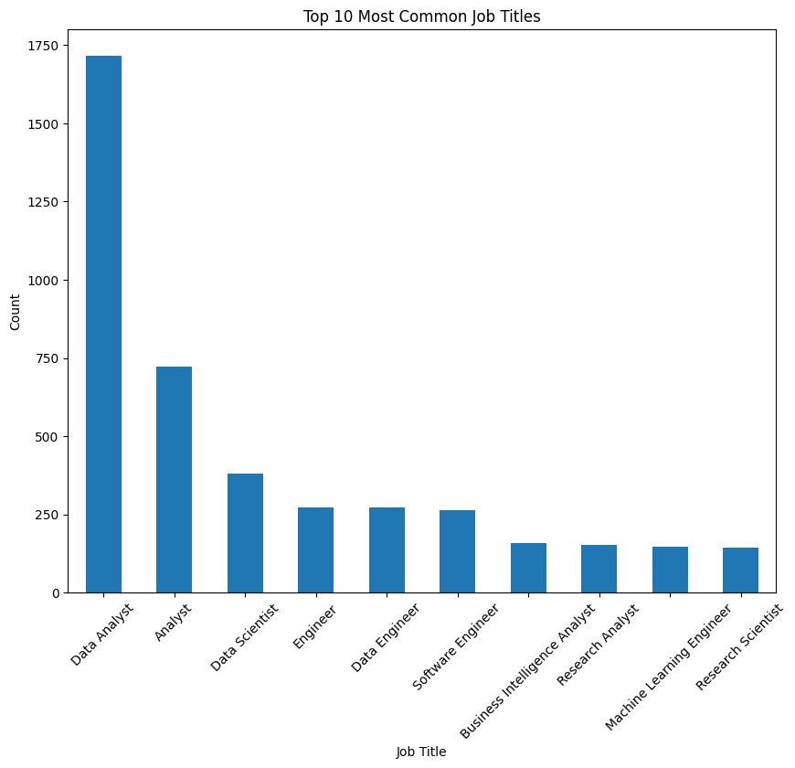

```python
#Visual 1 - FILL IN
top_10.plot(kind='bar', figsize = (10,8))
plt.title('Top 10 Most Common Job Titles')
plt.xlabel('Job Title')
plt.ylabel('Count')
plt.xticks(rotation = 45)
plt.show()
```

*Answer to research question:* The top 10 most common job titles for entry level data jobs are as above. The most striking for me was engineer and software engineer, as they weren't paths I had considered.

```python
# Set up average salary for top 10 most common job titles
df_10 = df[df['job_title'].isin(dict(top_10).keys())]
avg_sal_top_10 = df_10.groupby('job_title')['salary_usd'].mean()
```

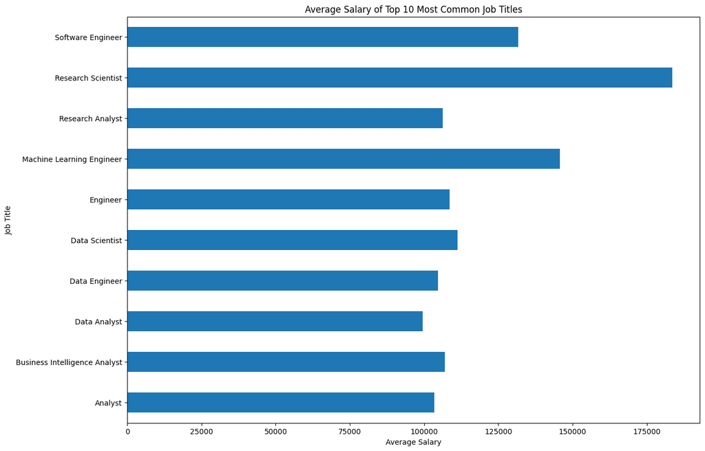

```python
# Plot the average salary of the top 10 most common job titles
avg_sal_top_10.plot(kind='barh', figsize = (14,10))
plt.title('Average Salary of Top 10 Most Common Job Titles')

plt.ylabel('Job Title')
plt.xlabel('Average Salary')

plt.show()
```

*Answer to research question:* Looks like the average salary for most of the jobs is around $100,000 with research scientist, machine learning engineer, and software engineer being quite a bit more.

### **5.2:** Reflection

In 2-4 sentences, if you had more time to complete the project, what actions would you take? For example, which data quality and structural issues would you look into further, and what research questions would you further explore?

*Answer:* I would probably scrape manually if I had more time as the datasets I found on kaggle were already very clean and made parts of this project difficult (figuring out what to clean and tidy). I would probably do some statistical testing as well